# Data Visualization

### Example 1:

Display the count of Pokémon introduced in each generation using **bar chart** with the 'generation_id' column.

|  | id | species | generation_id | height | weight | base_experience | type_1 | type_2 | hp | attack | defense | speed | special-attack | special-defense |
| --- | --- | --- | --- | --- | --- | --- | --- | --- | --- | --- | --- | --- | --- | --- |
| 0 | 1 | bulbasaur | 1 | 0.7 | 6.9 | 64 | grass | poison | 45 | 49 | 49 | 45 | 65 | 65 |
| 1 | 2 | ivysaur | 1 | 1.0 | 13.0 | 142 | grass | poison | 60 | 62 | 63 | 60 | 80 | 80 |
| 2 | 3 | venusaur | 1 | 2.0 | 100.0 | 236 | grass | poison | 80 | 82 | 83 | 80 | 100 | 100 |
| 3 | 4 | charmander | 1 | 0.6 | 8.5 | 62 | fire | NaN | 39 | 52 | 43 | 65 | 60 | 50 |
| 4 | 5 | charmeleon | 1 | 1.1 | 19.0 | 142 | fire | NaN | 58 | 64 | 58 | 80 | 80 | 65 |

```
array([1, 2, 3, 4, 5, 6, 7])
```

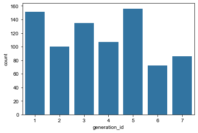

### Example 2:

Using **bar chart**, display the total count of Pokémon based on *type*.

*Notice:* Each Pokémon species has either type_1, type_2 or both types that play a part in its offensive and defensive capabilities.

**STEPS:**

1. Select the `id`, and `species` columns from pokemon.
2. Remove the `type_1`, `type_2` columns from pokemon
3. Add a new column `type_level` that can have a value either `type_1` or `type_2`
4. Add another column `type` that will contain the actual value contained in the `type_1`, `type_2` columns.

|  | id | species | generation_id | height | weight | base_experience | type_1 | type_2 | hp | attack | defense | speed | special-attack | special-defense |
| --- | --- | --- | --- | --- | --- | --- | --- | --- | --- | --- | --- | --- | --- | --- |
| 0 | 1 | bulbasaur | 1 | 0.7 | 6.9 | 64 | grass | poison | 45 | 49 | 49 | 45 | 65 | 65 |
| 1 | 2 | ivysaur | 1 | 1.0 | 13.0 | 142 | grass | poison | 60 | 62 | 63 | 60 | 80 | 80 |
| 2 | 3 | venusaur | 1 | 2.0 | 100.0 | 236 | grass | poison | 80 | 82 | 83 | 80 | 100 | 100 |
| 3 | 4 | charmander | 1 | 0.6 | 8.5 | 62 | fire | NaN | 39 | 52 | 43 | 65 | 60 | 50 |
| 4 | 5 | charmeleon | 1 | 1.1 | 19.0 | 142 | fire | NaN | 58 | 64 | 58 | 80 | 80 | 65 |

|  | species | type_level | type |
| --- | --- | --- | --- |
| 0 | bulbasaur | type_1 | grass |
| 1 | ivysaur | type_1 | grass |
| 2 | venusaur | type_1 | grass |
| 3 | charmander | type_1 | fire |
| 4 | charmeleon | type_1 | fire |

|  | species | type_level | type |
| --- | --- | --- | --- |
| 0 | bulbasaur | type_1 | grass |
| 1 | ivysaur | type_1 | grass |
| 2 | venusaur | type_1 | grass |
| 3 | charmander | type_1 | fire |
| 4 | charmeleon | type_1 | fire |
| ... | ... | ... | ... |
| 1207 | magearna | type_2 | fairy |
| 1208 | marshadow | type_2 | ghost |
| 1209 | naganadel | type_2 | dragon |
| 1210 | stakataka | type_2 | steel |
| 1211 | blacephalon | type_2 | ghost |

1212 rows × 3 columns

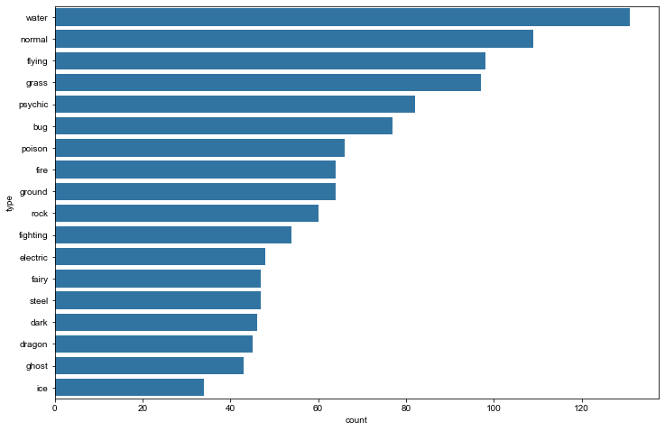

*Variations*:

Create a relative frequency plot of the proportion of Pokémon with each type, sorted from most frequent to least.

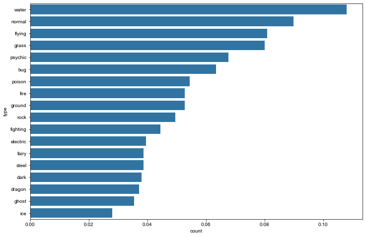

[output not shown]

[output not shown]